# Semesterbegleitende Abgabe WiSe2026-27

# Statistik im Bachelor Wirtschaftsinformatik

Dozent_innen: Martin Spott, Michael Heimann, Anja Hirsch  
Stand: 09.11.2026

**Gruppe:**

Gruppe D

**Autor_innen:**

Jakob Fahr  
Anahita Karimi  
David Marcel Mayer  
Timo Wahl

## Einleitung

In diesem Semester beschäftigen wir uns mit Kraftstoffpreisen in Berlin. Dazu benutzen wir Daten von der Organisation Tankerkönig [1], die jede Preisänderung angeschlossener Tankstellenbetreiber_innen mit Zeitstempel protokolliert. In der Datei *tankerkoenig_WiSe2026-27_1.csv* finden Sie den Ausschnitt der Daten, den Sie für die Aufgaben benutzen sollen. Dabei haben wir für jede Tankstelle und jede Stunde den Median der von Tankerkönig registrierten Preisänderungen der Kraftstoffe Diesel und E10 ermittelt.

### Regeln

Arbeiten Sie in Ihrer Moodlegruppe von bis zu vier Studierenden, die alle in derselben Übungsgruppe sein und die eine zu wählende Abgabe auch in den zugehörigen Übungen vorstellen müssen (Terminkalender folgt). Jede/r von Ihnen hat in Moodle nur Zugriff auf die Gruppeneinteilung Ihrer in LSF festgelegten Übungsgruppe, wo Sie sich in einer Gruppe eintragen müssen, um Punkte zu bekommen.

Bearbeiten Sie die Aufgaben fortlaufend in diesem RMarkdown-Dokument und **geben es bei jeder Teilabgabe komplett als RMarkdown- und als mit Knit übersetztes HTML-Dokument ab**. Stellen Sie sicher, dass das RMarkdown-Dokument auch für uns lauffähig ist. Gehen Sie dazu davon aus, dass sich auf unseren Rechnern die Daten im selben Verzeichnis befinden werden wie Ihr RMarkdown-Dokument.

Benutzen Sie nur Verfahren und Techniken, die wir in der Vorlesung besprochen haben. Sie können aber gerne komplexere Visualisierungen einsetzen, wenn dies sinnvoll erscheint.

Erklären Sie kurz Ihr Vorgehen vor jedem Codeabschnitt und interpretieren die Ergebnisse danach. Schreiben Sie Erklärungen/Interpretationen in Textform zwischen die Codeblöcke, nicht als Kommentare in die Codeblöcke. Sie können den Code aber gerne zusätzlich knapp kommentieren.

Für jede weitere Woche bekommen Sie eine Aufgabenstellung in RMarkdown, die Sie bitte in diesem Dokument fortlaufend anhängen und dort bearbeiten. Geben Sie immer das gesamte Dokument einschließlich der vorangehenden Aufgaben ab, da die Aufgaben teilweise aufeinander aufbauen und Sie vorangehende Lösungen später benötigen.

## Woche 1 – 27.10.2026

Beschreiben Sie zwischen den Codeblöcken in Textform, was Sie warum tun und was Sie herausfinden.

1. Importieren Sie die Daten.
2. Beschreiben Sie die Daten. Was sind die Merkmale, was die Merkmalsträger?
3. Geben Sie für alle Merkmale an, ob sie qualitativ/quantitativ, diskrekt/stetig und auf welchen Skalen sie definiert sind.
4. Berechnen Sie für das Merkmal `brand` (Marke) die Tabellen mit absoluter und relativer Häufigkeit.
5. Stellen Sie die Tabelle absoluter Häufigkeit von `brand` als Balkendiagramm dar. Beschriften Sie alle Axen und geben dem Diagramm eine Überschrift.
6. Was bedeuten die absoluten Häufigkeiten im Kontext unserer Daten? Warum gibt es Unterschiede zwischen den Werten der verschiedenen Marken?

### a. Datenimport

Die Daten liegen im CSV Format. Wir lesen sie mit `read.csv()` ein und speichern sie unter dem Namen `tanken`, damit wir sie in den folgenden Aufgaben auswerten können.

```r
   tanken <- read.csv("tankerkoenig_WiSe2026-27_1.csv")
```

Der Datensatz enthält 478274 Zeilen und 13 Spalten.

### b. Beschreibung der Daten

Um uns einen Überblick zu verschaffen, lassen wir uns die ersten Zeilen und die Struktur der Daten anzeigen.

```r
head(tanken)
```

```
##   X                                   id       date  time            name brand
## 1 0 005056ba-7cb6-1ed2-bceb-6d1d63fd4d20 2025-02-01 07:30 star Tankstelle  STAR
## 2 1 005056ba-7cb6-1ed2-bceb-6d1d63fd4d20 2025-02-01 08:30 star Tankstelle  STAR
## 3 2 005056ba-7cb6-1ed2-bceb-6d1d63fd4d20 2025-02-01 09:30 star Tankstelle  STAR
## 4 3 005056ba-7cb6-1ed2-bceb-6d1d63fd4d20 2025-02-01 10:30 star Tankstelle  STAR
## 5 4 005056ba-7cb6-1ed2-bceb-6d1d63fd4d20 2025-02-01 11:30 star Tankstelle  STAR
## 6 5 005056ba-7cb6-1ed2-bceb-6d1d63fd4d20 2025-02-01 12:30 star Tankstelle  STAR
##                  street house_number post_code opening_time closing_time
## 1 Finckensteinallee 133         <NA>     12205        07:00        22:00
## 2 Finckensteinallee 133         <NA>     12205        07:00        22:00
## 3 Finckensteinallee 133         <NA>     12205        07:00        22:00
## 4 Finckensteinallee 133         <NA>     12205        07:00        22:00
## 5 Finckensteinallee 133         <NA>     12205        07:00        22:00
## 6 Finckensteinallee 133         <NA>     12205        07:00        22:00
##   e10_median diesel_median
## 1         NA            NA
## 2       1779          1704
## 3       1709          1639
## 4       1684          1609
## 5       1649          1589
## 6       1679          1609
```

```r
str(tanken)
```

```
## 'data.frame':    478274 obs. of  13 variables:
##  $ X            : int  0 1 2 3 4 5 6 7 8 9 ...
##  $ id           : chr  "005056ba-7cb6-1ed2-bceb-6d1d63fd4d20" "005056ba-7cb6-1ed2-bceb-6d1d63fd4d20" "005056ba-7cb6-1ed2-bceb-6d1d63fd4d20" "005056ba-7cb6-1ed2-bceb-6d1d63fd4d20" ...
##  $ date         : chr  "2025-02-01" "2025-02-01" "2025-02-01" "2025-02-01" ...
##  $ time         : chr  "07:30" "08:30" "09:30" "10:30" ...
##  $ name         : chr  "star Tankstelle" "star Tankstelle" "star Tankstelle" "star Tankstelle" ...
##  $ brand        : chr  "STAR" "STAR" "STAR" "STAR" ...
##  $ street       : chr  "Finckensteinallee 133" "Finckensteinallee 133" "Finckensteinallee 133" "Finckensteinallee 133" ...
##  $ house_number : chr  NA NA NA NA ...
##  $ post_code    : int  12205 12205 12205 12205 12205 12205 12205 12205 12205 12205 ...
##  $ opening_time : chr  "07:00" "07:00" "07:00" "07:00" ...
##  $ closing_time : chr  "22:00" "22:00" "22:00" "22:00" ...
##  $ e10_median   : int  NA 1779 1709 1684 1649 1679 1699 1684 1709 1699 ...
##  $ diesel_median: int  NA 1704 1639 1609 1589 1609 1629 1619 1639 1619 ...
```

Der Datensatz enthält stündliche Kraftstoffpreise von Berliner Tankstellen. Der Merksmalsträger ist eine Tankstelle in einer bestimmten Stunde an einem bestimmten Tag. Grundgesamtheit sind alle Stunden der 78 Tankstellen in Berlin von Februar 2025 bis Januar 2026. Merkmale sind die Spalten: - `X`: die Zeilennummer - `id`: eindeutige ID der Tankstelle - `date`, `time`: Datum und Stunde - `name`, `brand`: Name und Marke der Tankstelle - `street`, `house_number`, `post_code`: Adresse der Tankstelle - `opening_time`, `closing_time`: Öffnungs und Schließzeit - `e10_median`, `diesel_median`: Median der Preise für E10 und Diesel in dieser Stunde. Die Preise sind in Euro pro Liter angegeben, aber ohne Komma.

Bei einigen Zeilen fehlen die Preise (`NA`).

### c. Merkmalstypen

| Merkmal | qualitativ/quantitativ | diskret/stetig | Skala |
| --- | --- | --- | --- |
| `X` | quantitativ | diskret | Ordinalskala |
| `id` | qualitativ | diskret | Nominalskala |
| `date` | quantitativ | diskret | Intervallskala |
| `time` | quantitativ | diskret | Intervallskala |
| `name` | qualitativ | diskret | Nominalskala |
| `brand` | qualitativ | diskret | Nominalskala |
| `street` | qualitativ | diskret | Nominalskala |
| `house_number` | qualitativ | diskret | Nominalskala |
| `post_code` | qualitativ | diskret | Nominalskala |
| `opening_time` | quantitativ | diskret | Intervallskala |
| `closing_time` | quantitativ | diskret | Intervallskala |
| `e10_median` | quantitativ | quasi-stetig | Verhältnisskala |
| `diesel_median` | quantitativ | quasi-stetig | Verhältnisskala |

Postleitzahl, Hausnummer und id bestehen zwar teilweise aus Ziffern, sind aber nur Bezeichnungen, mit denen man nicht rechnen kann. Deshalb sind sie qualitativ und nominal. Datum und Uhrzeiten sind intervallskaliert. Abstände sind sinnvoll, aber der Nullpunkt ist willkürlich. Die Preise sind verhältnisskaliert, weil 0 € ein echter Nullpunkt ist. Sie sind quasi-stetig, weil sie gerundet angegeben werden.

### d. Häufigkeiten der Marken

Wir zählen mit `table()`, wie oft jede Marke im Datensatz vorkommt (absolute Häufigkeit), und rechnen das mit `prop.table()` in Anteile um (relative Häufigkeit). Die Anteile runden wir mit `round()` auf drei Nachkommastellen.

```r
brand_abs <- table(tanken$brand)
brand_abs
```

```
##
##      AGIP ENI          ARAL          ESSO           HEM           JET
##         23595         52758         34385         35734         30489
##         Shell        Sprint          STAR TotalEnergies
##         95828         36423        102928         66134
```

```r
brand_rel <- prop.table(brand_abs)
round (brand_rel, 3)
```

```
##
##      AGIP ENI          ARAL          ESSO           HEM           JET
##         0.049         0.110         0.072         0.075         0.064
##         Shell        Sprint          STAR TotalEnergies
##         0.200         0.076         0.215         0.138
```

### e. Balkendiagramm

Da `brand` ein qualitatives Merkmal ist, stellen wir die absoluten Häufigkeiten als Balkendiagramm dar. Damit alle Markennamen lesbar sind, verkleinern wir sie (mit `cex.names`) und drehen sie senkrecht (mit `las = 2`).

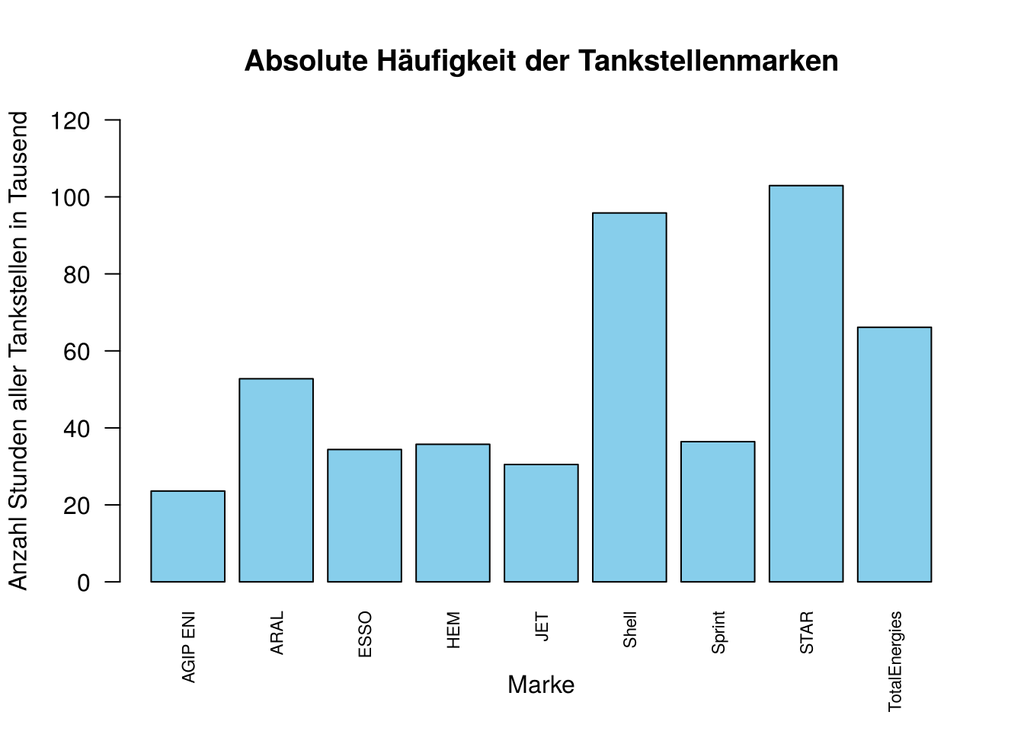

```r
barplot(brand_abs/1000,
        main = "Absolute Häufigkeit der Tankstellenmarken",
        xlab = "Marke",
        ylab = "Anzahl Stunden aller Tankstellen in Tausend",
        ylim = c(0, 120),
        cex.names = 0.7,
        las = 2,
        col = "skyblue")
```

Auf der x Achse sind die Tankstellenmarken. Auf der y Achse ist die absolute Häufigkeit dargestellt, also die Anzahl der Stunden, für die im Datensatz ein Preis einer Tankstelle dieser Marke vorliegt (zusammengezählt über alle Tankstellen der Marke und das ganze Jahr). Jeder Balken steht für eine Marke, und seine Höhe zeigt, wie oft diese Marke im Datensatz vorkommt. Am häufigsten kommt STAR vor, dicht gefolgt von Shell. Mit Abstand folgt TotalEnergies, am seltensten ist AGIP ENI.

### f. Interpretation der Häufigkeiten

Die absolute Häufigkeit einer Marke gibt an, für wie viele Stunden im Datensatz ein Preis einer Tankstelle dieser Marke vorliegt, zusammengezählt über alle Berliner Tankstellen der Marke im Zeitraum von Februar 2025 bis Januar 2026.

Die Unterschiede können vor allem durch die Anzahl der Tankstellen je Marke entstehen. STAR hat im Datensatz 17 Tankstellen, Shell 15, AGIP ENI dagegen nur 4. Je mehr Tankstellen eine Marke hat, desto mehr Stunden kommen zusammen. Außerdem sind die Öffnungszeiten auch relevant, je länger eine Tankstelle geöffnet hat, desto mehr Stunden mit Preisen gibt es im Datensatz.

```r
tankstellen <- unique(tanken[, c("id", "brand")])
table(tankstellen$brand)
```

```
##
##      AGIP ENI          ARAL          ESSO           HEM           JET
##             4             9             6             5             5
##         Shell        Sprint          STAR TotalEnergies
##            15             6            17            11
```

**—Fügen Sie hier kommende Aufgabenbeschreibungen mit Lösungen ein —**

## Woche 2

1. Bestimmen Sie, wie viele Werte bei jedem Merkmal im Datensatz fehlen (NA). Finden Sie mit Detektivarbeit heraus, welche Eigenschaft die Datensätze mit den fehlenden Werten haben und wie man die fehlenden mit sinnvollen Werten ersetzen kann. Das Ersetzen müssen Sie nur erklären, nicht implementieren.
2. Bestimmen Sie, zu welchen Uhrzeiten Messungen durchgeführt wurden und jeweils wie viele. Finden Sie mit Detektivarbeit heraus, welche Eigenschaften die Datensätze mit Messungen haben, die nicht bei voller Stunde vorgenommen wurden. Runden Sie die Zeit von allen Datensätzen zur nächsten vollen Stunde ab (streichen die Minuten), um später einfacher mit den Daten arbeiten zu können.
3. Finden Sie heraus, ob Merkmalsträger komplett fehlen. Wenn ja, können Sie ein Muster für das Fehlen erkennen?

### a. Fehlende Werte

Mit `is.na()` wird für jeden Wert geprüft, ob er fehlt.`colSums()` zählt dann die fehlenden Werte für jede Spalte. Mit `mean()` berechnen wir zusätzlich den Anteil der fehlenden Preise.

```r
colSums(is.na(tanken))
```

```
##             X            id          date          time          name
##             0             0             0             0             0
##         brand        street  house_number     post_code  opening_time
##             0             0         85868             0             0
##  closing_time    e10_median diesel_median
##             0         28151         28151
```

```r
mean(is.na(tanken$e10_median))
```

```
## [1] 0.05885957
```

```r
mean(is.na(tanken$diesel_median))
```

```
## [1] 0.05885957
```

Fehlende Werte gibt es nur bei `house_number`, `e10_median` und `diesel_median`. Bei `house_number` fehlen 85868 Werte. Das liegt daran, dass die Hausnummer schon in `street` steht. Bei `e10_median` und `diesel_median` fehlen jeweils 28151 Werte, also etwa 5,9 % aller Zeilen. Da es bei beiden genau gleich viele sind, fehlen wahrscheinlich immer beide Preise gleichzeitig.

Um herauszufinden, was die Zeilen mit fehlenden Preisen gemeinsam haben, filtern wir nur die Zeilen, in denen `e10_median` fehlt, und speichern sie als `fehlende_preise`. Mit `head()` schauen wir uns die ersten 15 Zeilen an.

```r
fehlende_preise <- tanken[is.na(tanken$e10_median) ,]
head(fehlende_preise, 15)
```

```
##         X                                   id       date  time            name
## 1       0 005056ba-7cb6-1ed2-bceb-6d1d63fd4d20 2025-02-01 07:30 star Tankstelle
## 98     97 005056ba-7cb6-1ed2-bceb-6d1d63fd4d20 2025-02-08 07:30 star Tankstelle
## 270   269 005056ba-7cb6-1ed2-bceb-6d1d63fd4d20 2025-02-20 07:30 star Tankstelle
## 300   299 005056ba-7cb6-1ed2-bceb-6d1d63fd4d20 2025-02-22 07:30 star Tankstelle
## 325   324 005056ba-7cb6-1ed2-bceb-6d1d63fd4d20 2025-02-24 07:30 star Tankstelle
## 340   339 005056ba-7cb6-1ed2-bceb-6d1d63fd4d20 2025-02-25 07:30 star Tankstelle
## 796   795 005056ba-7cb6-1ed2-bceb-6d1d63fd4d20 2025-03-29 07:30 star Tankstelle
## 824   823 005056ba-7cb6-1ed2-bceb-6d1d63fd4d20 2025-03-31 07:30 star Tankstelle
## 863   862 005056ba-7cb6-1ed2-bceb-6d1d63fd4d20 2025-04-03 07:30 star Tankstelle
## 877   876 005056ba-7cb6-1ed2-bceb-6d1d63fd4d20 2025-04-04 07:30 star Tankstelle
## 1017 1016 005056ba-7cb6-1ed2-bceb-6d1d63fd4d20 2025-04-14 07:30 star Tankstelle
## 1073 1072 005056ba-7cb6-1ed2-bceb-6d1d63fd4d20 2025-04-18 07:30 star Tankstelle
## 1088 1087 005056ba-7cb6-1ed2-bceb-6d1d63fd4d20 2025-04-19 07:30 star Tankstelle
## 1116 1115 005056ba-7cb6-1ed2-bceb-6d1d63fd4d20 2025-04-21 07:30 star Tankstelle
```

[output cut: 33 more lines]

In allen Zeilen fehlt auch `diesel_median`. Außerdem ist die Uhrzeit immer 07:30, also die erste Stunde nach der Öffnung um 07:00. Das sind aber alles Zeilen von derselben Tankstelle. Deshalb prüfen wir mit `table()`, ob das Muster auch bei den anderen Tankstellen gilt.

```r
table(fehlende_preise$time)
```

```
##
## 00:00 01:00 02:00 03:00 04:00 05:00 06:00 06:15 06:30 07:00 07:30 08:00 08:30
##  3115  3051  3053  3031  3818  2292  1681     3     6  2822   194   436     4
## 09:00 09:30 10:00 10:30 11:00 11:30 12:00 12:30 13:00 13:30 14:00 14:30 15:00
##   371     2   364     2   359     2   351     2   332     2   327     2   322
## 15:30 16:00 16:30 17:00 17:30 18:00 18:30 19:00 19:30 20:00 20:30 21:00 21:30
##     2   324     2   310     2   311     1   312     1   304     1   289     1
## 22:00 22:30 23:00
##   283     1    63
```

```r
table(fehlende_preise$opening_time)
```

```
##
## 00:00 04:00 05:00 06:00 07:00 08:00
## 16875   783  1097  7633  1751    12
```

Die meisten fehlenden Preise gibt es nachts und früh morgens zwischen 00:00 und 07:00 Uhr. Tagsüber fehlen nur etwa 300 Werte pro Stunde. Bei `opening_time` sieht man, dass 16875 der fehlenden Preise von Tankstellen kommen, die um 00:00 öffnen, also 24 Stunden offen haben. Danach kommen die Tankstellen, die um 06:00 öffnen.

Die Preise fehlen also immer am Anfang des Tages. Eine Tankstelle hat so lange keinen Preis, bis sie an dem Tag zum ersten Mal ihren Preis ändert. Bei Tankstellen, die 24 Stunden offen haben, ist das nachts, bei den anderen in der ersten Stunde nach dem Öffnen. Natürlich gibt es in dieser Zeit trotzdem einen Preis, er wurde nur noch nicht gemeldet. Deshalb konnte für diese Stunde kein Median berechnet werden.

**Ersetzen der fehlenden Werte:**

Weil ein Preis so lange gilt, bis er geändert wird, kann man einen fehlenden Wert durch den letzten bekannten Preis derselben Tankstelle ersetzen, also durch den letzten Preis vom Vortag. Dabei muss man darauf achten, nur Werte derselben Tankstelle zu nehmen und nicht einfach die Zeile darüber.

### b. Uhrzeiten der Messungen

Zuerst wird mit `table()` angezeigt, zu welchen Uhrzeiten Messungen vorliegen und wie viele es jeweils sind. Mit `length(unique())` zählen wir außerdem, wie viele verschiedene Uhrzeiten im Datensatz vorkommen.

```r
length(unique(tanken$time))
```

```
## [1] 58
```

```r
table(tanken$time)
```

```
##
## 00:00 01:00 02:00 03:00 04:00 05:00 06:00 06:15 06:30 07:00 07:15 07:30 08:00
##  3119  3064  3072  3050  3836  8934 21663   689   598 24774   694   992 25144
## 08:15 08:30 09:00 09:15 09:30 10:00 10:15 10:30 11:00 11:15 11:30 12:00 12:15
##   692  1039 25222   701  1040 25320   690  1040 25257   697  1044 25226   694
## 12:30 13:00 13:15 13:30 14:00 14:15 14:30 15:00 15:15 15:30 16:00 16:15 16:30
##  1032 25238   683  1036 25329   694  1033 25263   696  1041 25220   689  1041
## 17:00 17:15 17:30 18:00 18:15 18:30 19:00 19:15 19:30 20:00 20:15 20:30 21:00
## 24956   695  1044 25021   698  1039 24946   699  1035 24927   698  1049 23691
## 21:15 21:30 22:00 22:15 22:30 23:00
##   695  1046 21390   703   684  5972
```

Im Datensatz kommen 58 verschiedene Uhrzeiten vor. Neben den 24 vollen Stunden gibt es auch Messungen um xx:15 und xx:30

Die Uhrzeit liegt als Text im Format `"xx:xx"` vor. Mit `sub()` wird der Doppelpunkt durch einen leeren Text ersetzt, also gelöscht, sodass aus `"07:30"` die Zahl `730` wird. Mit der Ganzzahldivision `%/%` erhält man daraus die Stunde und mit dem Rest der Division `%%` die Minute

```r
zeit   <- as.integer(sub(":", "", tanken$time))
stunde <- zeit %/% 100
minute <- zeit %% 100

table(minute)
```

```
## minute
##      0     15     30
## 449634  11807  16833
```

Von den 478274 Messungen wurden 449634 zur vollen Stunde durchgeführt, 11807 zur Viertelstunde und 16833 zur halben Stunde.

```r
voll       <- tanken[minute == 0, ]
nicht_voll <- tanken[minute != 0, ]

table(nicht_voll$street)
```

```
##
##   Altentreptower Straße   Finckensteinallee 133      Steglitzer Damm 77
##                    5908                    5144                    5784
##       Teltower Damm 164 Waidmannsluster Damm 54
##                    5905                    5899
```

```r
length(unique(nicht_voll$id))
```

```
## [1] 5
```

```r
table(nicht_voll$time)
```

```
##
## 06:15 06:30 07:15 07:30 08:15 08:30 09:15 09:30 10:15 10:30 11:15 11:30 12:15
##   689   598   694   992   692  1039   701  1040   690  1040   697  1044   694
## 12:30 13:15 13:30 14:15 14:30 15:15 15:30 16:15 16:30 17:15 17:30 18:15 18:30
##  1032   683  1036   694  1033   696  1041   689  1041   695  1044   698  1039
## 19:15 19:30 20:15 20:30 21:15 21:30 22:15 22:30
##   699  1035   698  1049   695  1046   703   684
```

```r
table(nicht_voll$street, minute[minute != 0])
```

```
##
##                             15   30
##   Altentreptower Straße   5908    0
##   Finckensteinallee 133      0 5144
##   Steglitzer Damm 77         0 5784
##   Teltower Damm 164          0 5905
##   Waidmannsluster Damm 54 5899    0
```

Die meisten Messungen erfolgten zur vollen Stunde. Die Ausnahmen stammen ausschließlich von 5 Tankstellen, die ihre Preise immer zu einer festen Minute melden:

- **xx:15**: Altentreptower Straße, Waidmannsluster Damm 54
- **xx:30**: Finckensteinallee 133, Steglitzer Damm 77, Teltower Damm 164

Zum Schluss runden wir alle Uhrzeiten auf die volle Stunde ab, indem wir die Minuten streichen. Die Stunde haben wir oben bereits berechnet, bisher aber nur in der Variable `stunde` gespeichert. Mit `sprintf("%02d:00", stunde)` machen wir daraus wieder eine Uhrzeit im Format `"xx:00"`, wobei `%02d` die Stunde zweistellig mit führender Null schreibt.

```r
tanken$time <- sprintf("%02d:00", stunde)
table(tanken$time)
```

```
##
## 00:00 01:00 02:00 03:00 04:00 05:00 06:00 07:00 08:00 09:00 10:00 11:00 12:00
##  3119  3064  3072  3050  3836  8934 22950 26460 26875 26963 27050 26998 26952
## 13:00 14:00 15:00 16:00 17:00 18:00 19:00 20:00 21:00 22:00 23:00
## 26957 27056 27000 26950 26695 26758 26680 26674 25432 22777  5972
```

### c. Komplett fehlende Merkmalsträger

Ein Merkmalsträger ist eine Tankstelle in einer bestimmten Stunde an einem bestimmten Tag. Zuerst wird geprüft, wie viele Zeilen es theoretisch geben müsste, wenn für alle 78 Tankstellen an allen 365 Tagen jede der 24 Stunden vorhanden wäre.

```r
78 * 365 * 24
```

```
## [1] 683280
```

```r
nrow(tanken)
```

```
## [1] 478274
```

Bei 24 Stunden pro Tag gäbe es 683280 Merkmalsträger, wir haben aber nur 478274 Zeilen. Es fehlen also 205006 Stunden.

Grund: Öffnungszeiten. Es muss geprüft werden ob es im Datensatz überhaupt Zeilen außerhalb der Öffnungszeiten gibt, und dann muss berechnet werden, wie viele Stunden die Tankstellen insgesamt geöffnet haben.

```r
open_stunde  <- as.integer(sub(":00", "", tanken$opening_time))
close_stunde <- as.integer(sub(":00", "", tanken$closing_time))


sum(stunde < open_stunde)
```

```
## [1] 0
```

```r
sum(stunde >= close_stunde)
```

```
## [1] 0
```

```r
tag_info  <- tanken[!duplicated(tanken[, c("id", "date")]), ]
tag_open  <- as.integer(sub(":00", "", tag_info$opening_time))
tag_close <- as.integer(sub(":00", "", tag_info$closing_time))

sum(tag_close - tag_open)
```

```
## [1] 506484
```

```r
sum(tag_close - tag_open) - nrow(tanken)
```

```
## [1] 28210
```

Außerhalb der Öffnungszeiten gibt es 0 Zeilen. Insgesamt hatten alle Tankstellen im Jahr zusammen 506484 Stunden geöffnet. Damit fehlen schon mal $683280 - 506484 = 176796$ Merkmalsträger einfach deshalb, weil die Tankstellen nachts geschlossen hatten.

Allerdings fehlen auch innerhalb der Öffnungszeiten noch $506484 - 478274 = 28210$ Zeilen komplett. Um zu sehen, wann diese Zeilen fehlen, wird die erste Tankstelle an den ersten beiden Tagen näher betrachten. Des Weiteren wird geschaut für jede Stunde des Tages, wie viele geöffnete Stunden im Datensatz fehlen.

```r
tanken[1:14, c("date", "time", "opening_time", "closing_time", "e10_median")]
```

```
##          date  time opening_time closing_time e10_median
## 1  2025-02-01 07:00        07:00        22:00         NA
## 2  2025-02-01 08:00        07:00        22:00       1779
## 3  2025-02-01 09:00        07:00        22:00       1709
## 4  2025-02-01 10:00        07:00        22:00       1684
## 5  2025-02-01 11:00        07:00        22:00       1649
## 6  2025-02-01 12:00        07:00        22:00       1679
## 7  2025-02-01 14:00        07:00        22:00       1699
## 8  2025-02-01 15:00        07:00        22:00       1684
## 9  2025-02-01 16:00        07:00        22:00       1709
## 10 2025-02-01 17:00        07:00        22:00       1699
## 11 2025-02-01 18:00        07:00        22:00       1679
## 12 2025-02-01 19:00        07:00        22:00       1684
## 13 2025-02-01 20:00        07:00        22:00       1704
## 14 2025-02-01 21:00        07:00        22:00       1684
```

```r
offen_je_stunde <- sapply(0:23, function(h) sum(tag_open <= h & h < tag_close))
offen_je_stunde - as.integer(table(tanken$time))
```

```
##  [1]  166  221  213  235  229  491 1280 1435 1491 1507 1420 1472 1518 1513 1414
## [16] 1470 1520 1775 1712 1790 1796 1683 1573  286
```

Bei der ersten Tankstelle fehlt am `2025-02-01` mitten am Tag die Zeile für `13:00` Uhr (vor dem Abrunden `13:30`). Auch über den ganzen Datensatz verteilt fehlen tagsüber zwischen 06:00 und 22:00 Uhr in jeder Stunde rund 1300 bis 1800 Zeilen.

**Muster für das Fehlen der Merkmalsträger:**

1. **Geschlossene Stunden (176796 Zeilen):** Wenn eine Tankstelle geschlossen hat, wird für diese Stunden gar keine Zeile im Datensatz angelegt.
2. **Keine Preisänderung in dieser Stunde (28210 Zeilen):** Tankerkönig zeichnet nur Preisänderungen auf. Am Anfang des Tages (nach der Öffnung bis zur ersten Preismeldung) wurden die Stunden ohne Meldung zwar noch als Zeilen mit `NA` aufgefüllt (siehe Aufgabe a). Sobald an einem Tag aber der erste Preis gemeldet wurde, fehlt eine spätere Stunde komplett als Zeile im Datensatz, wenn die Tankstelle in dieser Stunde ihren Preis nicht geändert hat.

## Woche 3 – 10.11.2026

1. Erstellen Sie vollständig beschriftete Histogramme für die Merkmale `e10_median` und `diesel_median` und überlagern diese zum besseren Vergleich in einem Diagramm. Dazu können Sie auch Bibliotheken wie ggplot2 und plotly betrachten.
2. Bestimmen Sie Fünf- oder Sechs-Punkte-Zusammenfassungen der Merkmale `e10_median` und `diesel_median` und erstellen zugehörige Boxplots mit Ausreißererkennung.
3. Vergleichen Sie anhand der Histogramme, der Fünf- oder Sechs-Punkte-Zusammenfassungen sowie der Boxplots die Werteverteilungen von `e10_median` und `diesel_median`.
4. Extrahieren Sie die Ausreißer von `e10_median` und `diesel_median`. Finden Sie mit Detektivarbeit heraus,
   - ob es ein Muster für die Ausreißer gibt, z.B. wann sie wo auftreten
   - ob die Ausreißer echte oder falsche Werte sind.

### a. Histogramme

Die Preise sind in Zehntel-Cent pro Liter angegeben, der Wert 1649 bedeutet also 1,649 € pro Liter. Zuerst erstellen wir mit `hist()` für jede Kraftstoffsorte ein eigenes Histogramm. Damit beide Histogramme vergleichbar sind, verwenden wir für beide dieselben Klassengrenzen in 10er-Schritten. Mit `range(..., na.rm = TRUE)` bestimmen wir dafür den kleinsten und größten Preis beider Merkmale, die fehlenden Werte (siehe Woche 2) werden dabei ignoriert.

```r
grenzen <- seq(0, 2700, by = 10)
range(tanken$e10_median, tanken$diesel_median, na.rm = TRUE)
```

```
## [1]    0 2669
```

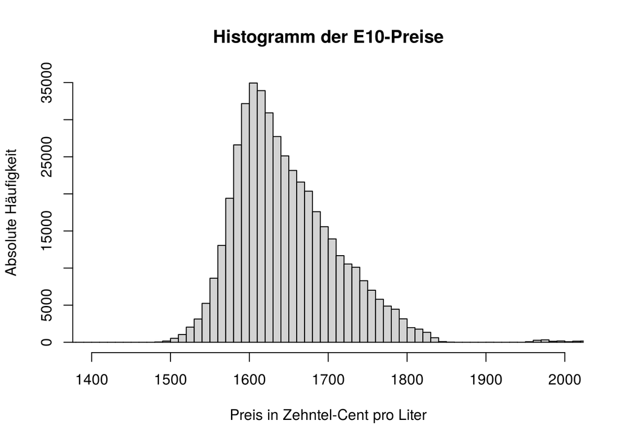

```r
hist(tanken$e10_median, breaks = grenzen, xlim = c(1400, 2000),
     main = "Histogramm der E10-Preise",
     xlab = "Preis in Zehntel-Cent pro Liter", ylab = "Absolute Häufigkeit")
```

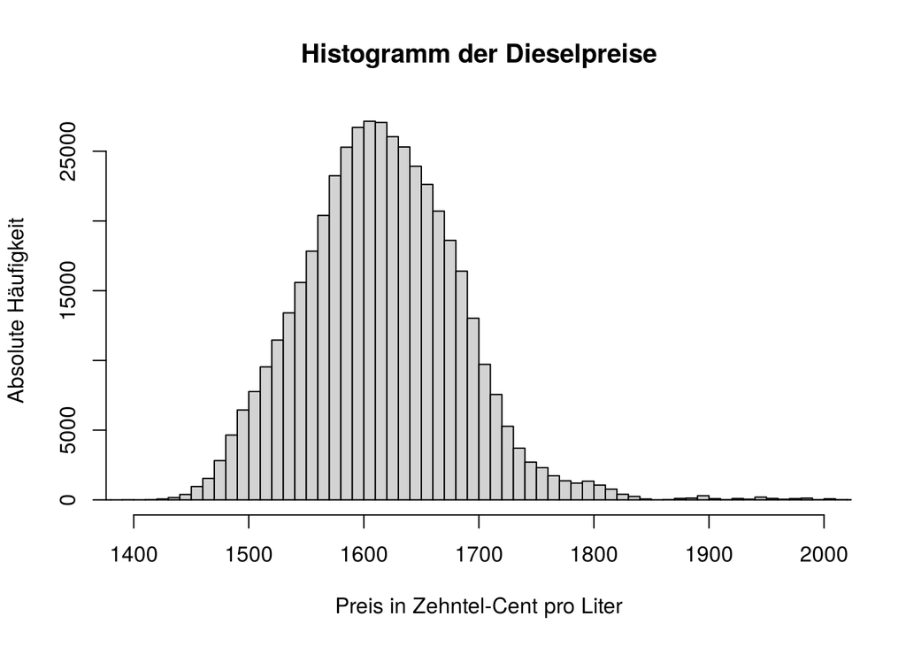

```r
hist(tanken$diesel_median, breaks = grenzen, xlim = c(1400, 2000),
     main = "Histogramm der Dieselpreise",
     xlab = "Preis in Zehntel-Cent pro Liter", ylab = "Absolute Häufigkeit")
```

Für den direkten Vergleich zeichnen wir beide Histogramme übereinander. Das zweite Histogramm wird mit `add = TRUE` in das erste Diagramm gezeichnet. Mit `rgb()` wählen wir halbdurchsichtige Farben (der vierte Wert ist die Deckkraft), damit man beide Verteilungen auch dort sieht, wo sie sich überlappen. Eine Legende zeigt, welche Farbe zu welcher Kraftstoffsorte gehört.

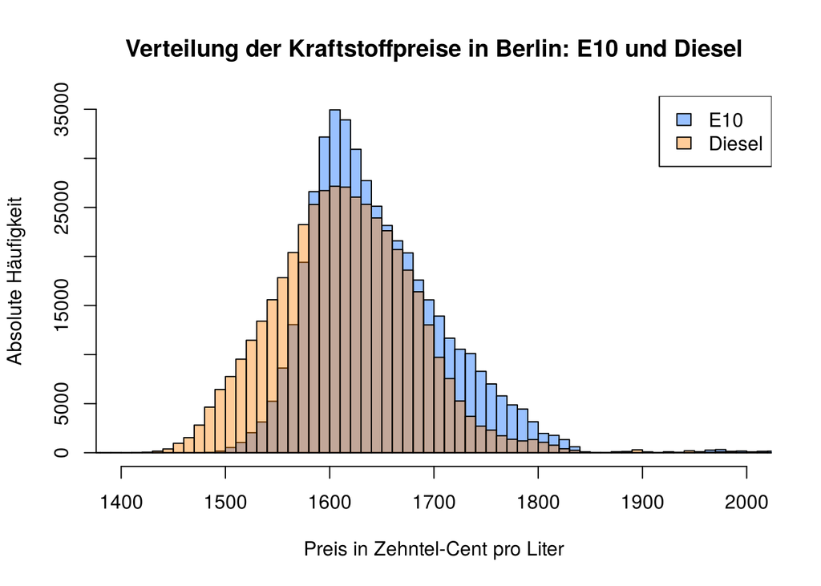

```r
farbe_e10    <- rgb(0, 0.4, 1, 0.4)   # blau, halbdurchsichtig
farbe_diesel <- rgb(1, 0.5, 0, 0.4)   # orange, halbdurchsichtig

hist(tanken$e10_median, breaks = grenzen, xlim = c(1400, 2000), col = farbe_e10,
     main = "Verteilung der Kraftstoffpreise in Berlin: E10 und Diesel",
     xlab = "Preis in Zehntel-Cent pro Liter", ylab = "Absolute Häufigkeit")
hist(tanken$diesel_median, breaks = grenzen, col = farbe_diesel, add = TRUE)
legend("topright", legend = c("E10", "Diesel"), fill = c(farbe_e10, farbe_diesel))
```

Beide Verteilungen sind eingipflig mit dem häufigsten Preis um 1600. E10 ist rechtsschief: Links fällt die Verteilung steil ab, nach rechts läuft sie bis etwa 1850 langsam aus. Diesel ist breiter gestreut und reicht weiter nach links bis etwa 1450, dafür nach rechts nicht so weit wie E10. Insgesamt liegt Diesel etwas weiter links, war im betrachteten Jahr also meistens etwas günstiger als E10. Rechts von 1850 gibt es bei beiden Kraftstoffen nur noch vereinzelte Werte.

### b. Fünf- bzw. Sechs-Punkte-Zusammenfassung und Boxplots

Die Sechs-Punkte-Zusammenfassung erhalten wir mit `summary()`. Sie enthält die Fünf-Punkte-Zusammenfassung (Minimum, unteres Quartil, Median, oberes Quartil, Maximum) und zusätzlich das arithmetische Mittel. `summary()` zeigt außerdem die Anzahl der fehlenden Werte (`NA's`) an. Mit `IQR()` berechnen wir zusätzlich den Interquartilsabstand, den wir für die Ausreißererkennung brauchen.

```r
summary(tanken$e10_median)
```

```
##    Min. 1st Qu.  Median    Mean 3rd Qu.    Max.    NA's
##    1484    1604    1639    1649    1689    2669   28151
```

```r
summary(tanken$diesel_median)
```

```
##    Min. 1st Qu.  Median    Mean 3rd Qu.    Max.    NA's
##       0    1569    1619    1618    1659    2619   28151
```

```r
IQR(tanken$e10_median, na.rm = TRUE)
```

```
## [1] 85
```

```r
IQR(tanken$diesel_median, na.rm = TRUE)
```

```
## [1] 90
```

|  | Minimum | 1. Quartil | Median | Mittelwert | 3. Quartil | Maximum | IQR |
| --- | --- | --- | --- | --- | --- | --- | --- |
| E10 | 1484 | 1604 | 1639 | 1649,4 | 1689 | 2669 | 85 |
| Diesel | 0 | 1569 | 1619 | 1618,1 | 1659 | 2619 | 90 |

Bei beiden Merkmalen fehlen 28151 Werte (siehe Woche 2).

Als Ausreißer gelten wie in der Vorlesung alle Werte, die mehr als das 1,5-fache des IQR unter dem unteren oder über dem oberen Quartil liegen. Wir berechnen diese Grenzen, um sie später mit den Boxplots zu vergleichen.

```r
q_e10    <- quantile(tanken$e10_median,    c(0.25, 0.75), na.rm = TRUE)
q_diesel <- quantile(tanken$diesel_median, c(0.25, 0.75), na.rm = TRUE)

grenzen_e10    <- c(q_e10[1]    - 1.5 * IQR(tanken$e10_median,    na.rm = TRUE),
                    q_e10[2]    + 1.5 * IQR(tanken$e10_median,    na.rm = TRUE))
grenzen_diesel <- c(q_diesel[1] - 1.5 * IQR(tanken$diesel_median, na.rm = TRUE),
                    q_diesel[2] + 1.5 * IQR(tanken$diesel_median, na.rm = TRUE))
grenzen_e10
```

```
##    25%    75%
## 1476.5 1816.5
```

```r
grenzen_diesel
```

```
##  25%  75%
## 1434 1794
```

Bei E10 sind also Preise unter 1476,5 oder über 1816,5 Ausreißer, bei Diesel Preise unter 1434 oder über 1794.

Die Boxplots zeichnen wir mit `boxplot()`. Die Funktion verwendet standardmäßig die erweiterte Version aus der Vorlesung: Die Whisker reichen höchstens bis zum 1,5-fachen IQR, alle Werte außerhalb werden einzeln als Punkte (Ausreißer) eingezeichnet. Wir stellen beide Merkmale nebeneinander dar, damit man sie direkt vergleichen kann.

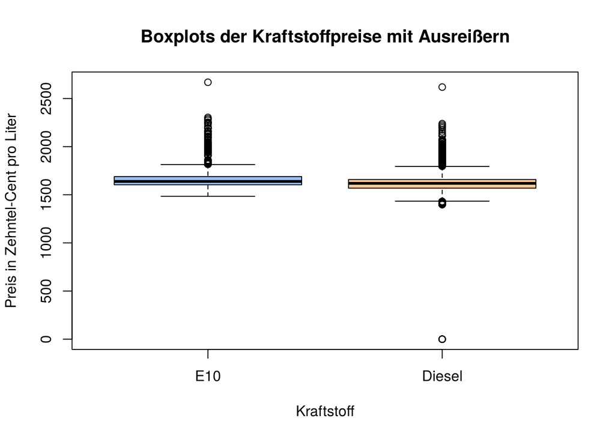

```r
boxplot(tanken$e10_median, tanken$diesel_median,
        names = c("E10", "Diesel"), col = c(farbe_e10, farbe_diesel),
        main = "Boxplots der Kraftstoffpreise mit Ausreißern",
        xlab = "Kraftstoff", ylab = "Preis in Zehntel-Cent pro Liter")
```

Weil der Diesel-Ausreißer bei 0 die Skala stark streckt, sind die Boxen in diesem Diagramm sehr klein. Deshalb zeichnen wir die Boxplots noch einmal mit einem Ausschnitt der y-Achse (`ylim`) von 1300 bis 2700. Der Wert 0 ist dann nicht mehr zu sehen, alle anderen Ausreißer schon.

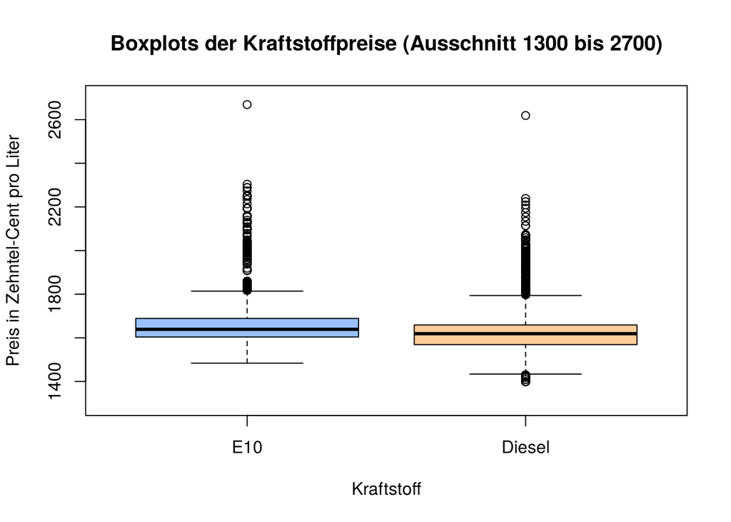

```r
boxplot(tanken$e10_median, tanken$diesel_median,
        names = c("E10", "Diesel"), col = c(farbe_e10, farbe_diesel),
        ylim = c(1300, 2700),
        main = "Boxplots der Kraftstoffpreise (Ausschnitt 1300 bis 2700)",
        xlab = "Kraftstoff", ylab = "Preis in Zehntel-Cent pro Liter")
```

Bei beiden Kraftstoffen gibt es sehr viele Ausreißer nach oben. Nach unten hat E10 keine Ausreißer, Diesel dagegen schon, darunter einige Werte von 0.

## Quellen

[1] Tankerkönig UG, URL: https://tankerkoenig.de, letzter Aufruf: 02.11.2026